# **Topic 11 - ggplot2: Grammar of Graphics**

# Exercises (Using `iris` Dataset)

The `iris` dataset contains 150 observations of iris flowers with 5 variables:

| Variable | Type | Description |
| --- | --- | --- |
| `Sepal.Length` | Quantitative | Sepal length in centimeters |
| `Sepal.Width` | Quantitative | Sepal width in centimeters |
| `Petal.Length` | Quantitative | Petal length in centimeters |
| `Petal.Width` | Quantitative | Petal width in centimeters |
| `Species` | Categorical | Species of iris (**setosa**, **versicolor**, **virginica**) |

## Exercise 1: Basic Scatterplot with Customization

Using the `iris` dataset, create a scatterplot showing the relationship between **sepal length** (`Sepal.Length`) and **petal length** (`Petal.Length`). Customize the points with:

- Blue color
- Size 3
- 70% transparency (`alpha = 0.7`)
- Diamond shape (`shape = 18`)

Add appropriate axis labels and a title “Sepal Length vs Petal Length in Iris Flowers”.

```
# Your code here:
```

## Solution

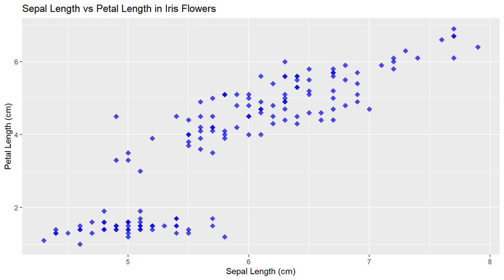

```r
ggplot(iris, aes(x = Sepal.Length, y = Petal.Length)) +
  geom_point(color = "blue", size = 3, alpha = 0.7, shape = 18) +
  labs(
    title = "Sepal Length vs Petal Length in Iris Flowers",
    x = "Sepal Length (cm)",
    y = "Petal Length (cm)"
  )
```

## Exercise 2: Adding a Trend Line

Starting from Exercise 1, add a linear regression trend line (`method = "lm"`) in red without showing the confidence interval (`se = FALSE`).

```
# Your code here:
```

## Solution

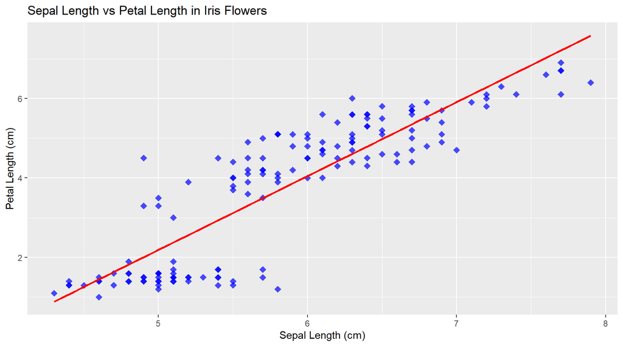

```r
ggplot(iris, aes(x = Sepal.Length, y = Petal.Length)) +
  geom_point(color = "blue", size = 3, alpha = 0.7, shape = 18) +
  geom_smooth(method = "lm", color = "red", se = FALSE) +
  labs(
    title = "Sepal Length vs Petal Length in Iris Flowers",
    x = "Sepal Length (cm)",
    y = "Petal Length (cm)"
  )
```

## Exercise 3: Mapping Variables to Aesthetics

Create a scatterplot of `Sepal.Length` vs `Petal.Width` where:

- Points are colored by `Species`
- Points are sized by `Sepal.Width`
- Add a title: “Iris Measurements by Species”
- Use a clean theme (e.g., `theme_minimal()`)

```
# Your code here:
```

## Solution

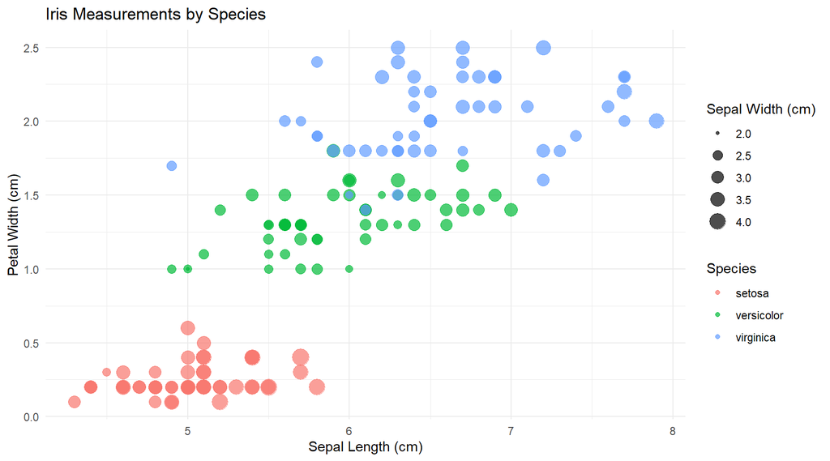

```r
ggplot(iris, aes(x = Sepal.Length, y = Petal.Width, color = Species, size = Sepal.Width)) +
  geom_point(alpha = 0.7) +
  labs(
    title = "Iris Measurements by Species",
    x = "Sepal Length (cm)",
    y = "Petal Width (cm)",
    color = "Species",
    size = "Sepal Width (cm)"
  ) +
  theme_minimal()
```

## Exercise 4: Bar Chart with Customization

Create a horizontal bar chart showing the count of flowers by `Species`:

- Bars should be filled with “darkgreen”
- Bars should have black borders (`color = "black"`)
- Add count labels on top of each bar
- Title: “Number of Flowers by Iris Species”
- Use `coord_flip()` to make it horizontal

```
# Your code here:
```

## Solution

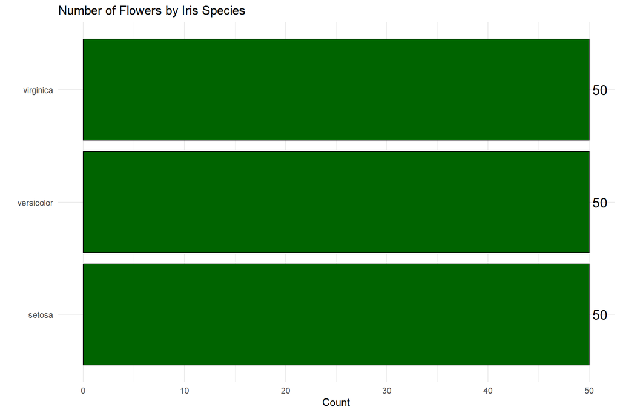

```r
iris %>%
  count(Species) %>%
  ggplot(aes(x = reorder(Species, n), y = n)) +
  geom_bar(stat = "identity", fill = "darkgreen", color = "black") +
  geom_text(aes(label = n), hjust = -0.2, size = 5) +
  coord_flip() +
  labs(
    title = "Number of Flowers by Iris Species",
    x = "",
    y = "Count"
  ) +
  theme_minimal()
```

## Exercise 5: Histogram with Density Curve

```
# Your code here:
```

## Solution

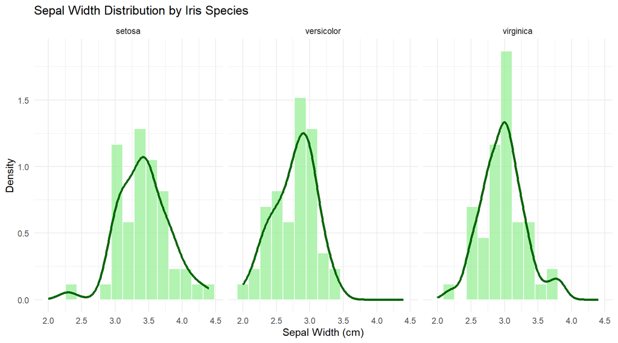

```r
ggplot(iris, aes(x = Sepal.Width, y = ..density..)) +
  geom_histogram(fill = "lightgreen", color = "white", bins = 15, alpha = 0.7) +
  geom_density(color = "darkgreen", size = 1.2) +
  facet_wrap(~Species, ncol = 3) +
  labs(
    title = "Sepal Width Distribution by Iris Species",
    x = "Sepal Width (cm)",
    y = "Density"
  ) +
  theme_minimal()
```

## Exercise 6: Boxplot by Category

Create a boxplot showing the distribution of `Petal.Length` for each Species:

- Fill the boxes by Species with the colors: `"#66C2A5" (setosa)`, `"#FC8D62" (versicolor)`, `"#8DA0CB" (virginica)`
- Add a title: “Petal Length Distribution by Iris Species”
- Add an informative subtitle

```
# Your code here:
```

## Solution

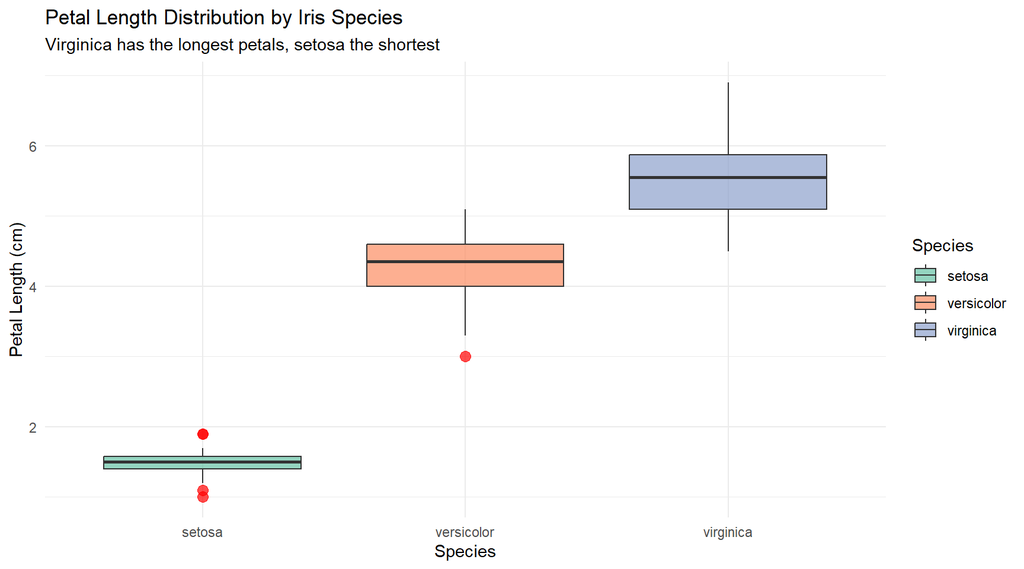

```r
ggplot(iris, aes(x = Species, y = Petal.Length, fill = Species)) +
  geom_boxplot(alpha = 0.7, outlier.color = "red", outlier.size = 3) +
  scale_fill_manual(values = c("setosa" = "#66C2A5",
                                "versicolor" = "#FC8D62",
                                "virginica" = "#8DA0CB")) +
  labs(
    title = "Petal Length Distribution by Iris Species",
    subtitle = "Virginica has the longest petals, setosa the shortest",
    x = "Species",
    y = "Petal Length (cm)",
    fill = "Species"
  ) +
  theme_minimal()
```

## Exercise 7: Faceting with `facet_wrap()`

Create a scatterplot of `Sepal.Length` vs `Petal.Length`:

- Color points by `Species`
- Add a linear regression line (`method = "lm"`) for each panel
- Use `facet_wrap()` to create panels by Species in 1 row
- Title: “Relationship Between Sepal Length and Petal Length by Species”

```
# Your code here:
```

## Solution

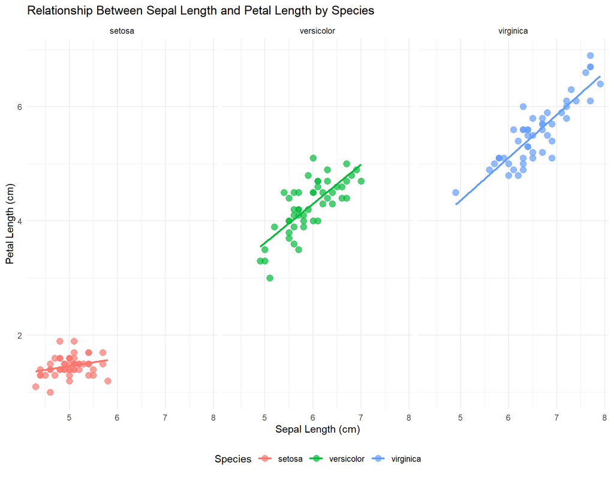

```r
ggplot(iris, aes(x = Sepal.Length, y = Petal.Length, color = Species)) +
  geom_point(alpha = 0.7, size = 3) +
  geom_smooth(method = "lm", se = FALSE, size = 1) +
  facet_wrap(~Species, nrow = 1) +
  labs(
    title = "Relationship Between Sepal Length and Petal Length by Species",
    x = "Sepal Length (cm)",
    y = "Petal Length (cm)",
    color = "Species"
  ) +
  theme_minimal() +
  theme(legend.position = "bottom")
```

## Exercise 8: Stacked vs. Grouped Bar Chart Comparison

**Part A:** Create a **stacked bar chart** (this will be less meaningful with iris since Species is the only categorical variable; instead, create a new categorical variable `Size_Category` based on Sepal.Length).

First, create a size category variable:

```r
iris_with_size <- iris %>%
  mutate(Size_Category = case_when(
    Sepal.Length < 5 ~ "Small",
    Sepal.Length < 6 ~ "Medium",
    TRUE ~ "Large"
  ))
```

Then create a **stacked bar chart** showing count by `Size_Category`, with fill representing `Species`.

**Part B:** Create a **grouped (dodged) bar chart** with the same variables.

```
# Part A: Your code here:

# Part B: Your code here:
```

## Solution

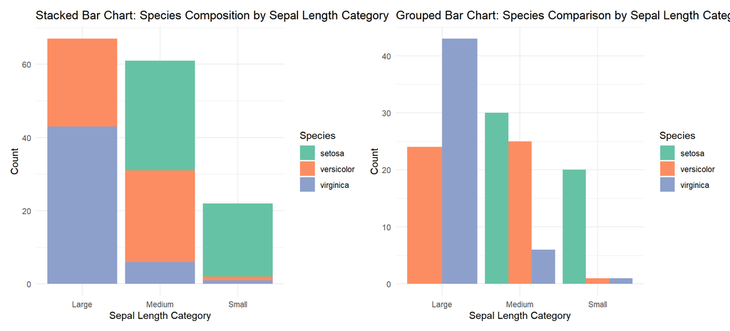

```r
# Create the data with size categories
iris_with_size <- iris %>%
  mutate(Size_Category = case_when(
    Sepal.Length < 5 ~ "Small",
    Sepal.Length < 6 ~ "Medium",
    TRUE ~ "Large"
  ))

# Part A: Stacked bar chart
p_stacked <- ggplot(iris_with_size, aes(x = Size_Category, fill = Species)) +
  geom_bar(position = "stack") +
  scale_fill_manual(values = c("setosa" = "#66C2A5",
                                "versicolor" = "#FC8D62",
                                "virginica" = "#8DA0CB")) +
  labs(
    title = "Stacked Bar Chart: Species Composition by Sepal Length Category",
    x = "Sepal Length Category",
    y = "Count",
    fill = "Species"
  ) +
  theme_minimal()

# Part B: Grouped bar chart
p_dodged <- ggplot(iris_with_size, aes(x = Size_Category, fill = Species)) +
  geom_bar(position = "dodge") +
  scale_fill_manual(values = c("setosa" = "#66C2A5",
                                "versicolor" = "#FC8D62",
                                "virginica" = "#8DA0CB")) +
  labs(
    title = "Grouped Bar Chart: Species Comparison by Sepal Length Category",
    x = "Sepal Length Category",
    y = "Count",
    fill = "Species"
  ) +
  theme_minimal()

# Display both (requires patchwork package)
library(patchwork)
p_stacked + p_dodged
```

## Exercise 9: Complete Data Visualization Pipeline

Using the `iris` dataset, create a comprehensive visualization that:

- Filters to only `setosa` and `versicolor` species
- Creates a scatterplot of `Sepal.Length` vs `Sepal.Width`
- Colors points by `Species`
- Uses different point shapes based on `Species`
- Adds a smooth trend line (`LOESS` not linear) without standard error
- Facets by `Species` in 2 columns
- Adds a meaningful title, subtitle, and axis labels

```
# Your code here:
```

## Solution

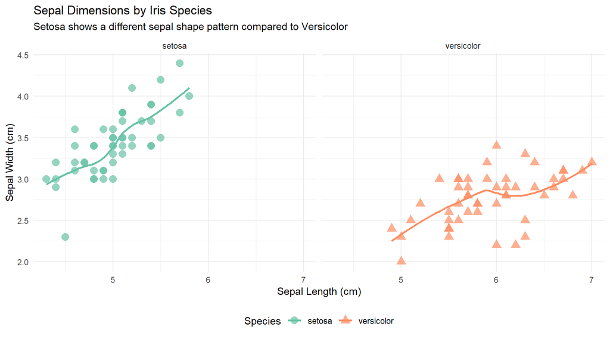

```r
iris %>%
  filter(Species %in% c("setosa", "versicolor")) %>%
  ggplot(aes(x = Sepal.Length, y = Sepal.Width, color = Species, shape = Species)) +
  geom_point(size = 3.5, alpha = 0.7) +
  geom_smooth(se = FALSE, method = "loess", size = 1) +
  facet_wrap(~Species, ncol = 2) +
  labs(
    title = "Sepal Dimensions by Iris Species",
    subtitle = "Setosa shows a different sepal shape pattern compared to Versicolor",
    x = "Sepal Length (cm)",
    y = "Sepal Width (cm)",
    color = "Species",
    shape = "Species"
  ) +
  scale_color_manual(values = c("setosa" = "#66C2A5", "versicolor" = "#FC8D62")) +
  scale_shape_manual(values = c(16, 17)) +
  theme_minimal() +
  theme(legend.position = "bottom")
```

## Exercise 10: Advanced Customization Challenge

Create a publication-ready plot that answers the question: **“How does the relationship between sepal length and petal length differ by iris species?”**

Requirements:

- Scatterplot with `Sepal.Length` on x-axis, `Petal.Length` on y-axis
- Color by `Species`
- Add linear regression lines for each species with confidence intervals
- Add a separate panel for each species using faceting
- Customize colors using a meaningful palette
- Add a title and subtitle
- Add caption: “Data Source: Edgar Anderson’s Iris Dataset (1935)”
- Apply a professional theme
- Add axis labels with units

```
# Your code here:
```

## Solution

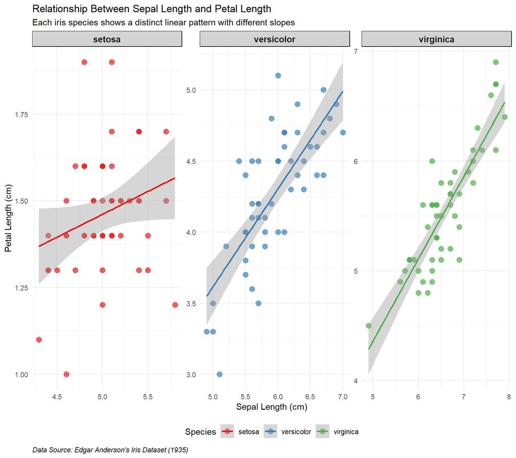

```r
ggplot(iris, aes(x = Sepal.Length, y = Petal.Length, color = Species)) +
  geom_point(size = 3, alpha = 0.7) +
  geom_smooth(method = "lm", se = TRUE, size = 1) +
  facet_wrap(~Species, ncol = 3, scales = "free") +
  labs(
    title = "Relationship Between Sepal Length and Petal Length",
    subtitle = "Each iris species shows a distinct linear pattern with different slopes",
    x = "Sepal Length (cm)",
    y = "Petal Length (cm)",
    caption = "Data Source: Edgar Anderson's Iris Dataset (1935)",
    color = "Species"
  ) +
  scale_color_brewer(palette = "Set1") +
  theme_minimal() +
  theme(
    legend.position = "bottom",
    strip.background = element_rect(fill = "lightgray"),
    strip.text = element_text(face = "bold", size = 11),
    plot.caption = element_text(hjust = 0, face = "italic")
  )
```